# MARKET SEGMENTATION FOR AIRLINES

# Name: Hwansoo Joo/ Ji Eun Seo/ Rahul Gaur/ Atul Shukla

# Date: 27/01/2017

## *Introduction*

Market segmentation is a strategy that divides a broad target market of customers into smaller, more similar groups, and then designs a marketing strategy specifically for each group. Clustering is a common technique for market segmentation since it automatically finds similar groups given a data set.

Here we see how clustering can be used to find similar groups of customers who belong to an airline’s frequent flyer program. The airline is trying to learn more about its customers so that it can target different customer segments with different types of mileage offers.

The file “AirlinesCluster.csv”" contains information on 3,999 members of the frequent flyer program.

There are seven different variables in the dataset, described below:

```
Balance = number of miles eligible for award travel
QualMiles = number of miles qualifying for TopFlight status
BonusMiles = number of miles earned from non-flight bonus transactions in the past 12 months
BonusTrans = number of non-flight bonus transactions in the past 12 months
FlightMiles = number of flight miles in the past 12 months
FlightTrans = number of flight transactions in the past 12 months
DaysSinceEnroll = number of days since enrolled in the frequent flyer program
```

## *NORMALIZING THE DATA*

```r
# Data
airlines <- read.csv("AirlinesCluster.csv")
summary(airlines)
```

```
##     Balance          QualMiles         BonusMiles       BonusTrans
##  Min.   :      0   Min.   :    0.0   Min.   :     0   Min.   : 0.0
##  1st Qu.:  18528   1st Qu.:    0.0   1st Qu.:  1250   1st Qu.: 3.0
##  Median :  43097   Median :    0.0   Median :  7171   Median :12.0
##  Mean   :  73601   Mean   :  144.1   Mean   : 17145   Mean   :11.6
##  3rd Qu.:  92404   3rd Qu.:    0.0   3rd Qu.: 23801   3rd Qu.:17.0
##  Max.   :1704838   Max.   :11148.0   Max.   :263685   Max.   :86.0
##   FlightMiles       FlightTrans     DaysSinceEnroll
##  Min.   :    0.0   Min.   : 0.000   Min.   :   2
##  1st Qu.:    0.0   1st Qu.: 0.000   1st Qu.:2330
##  Median :    0.0   Median : 0.000   Median :4096
##  Mean   :  460.1   Mean   : 1.374   Mean   :4119
##  3rd Qu.:  311.0   3rd Qu.: 1.000   3rd Qu.:5790
##  Max.   :30817.0   Max.   :53.000   Max.   :8296
```

```r
# Create a normalized data frame called "airlinesNorm".If we don't normalize the data, the variables that are on a larger scale will contribute much more to the distance calculation, and thus will dominate the clustering.

library(caret)
# Normalize the variables in the airlines data frame by using the preProcess function in the "caret" package
# Pre process
preproc = preProcess(airlines)
# Normalize
airlinesNorm = predict(preproc, airlines)
summary(airlinesNorm)
```

```
##     Balance          QualMiles         BonusMiles        BonusTrans
##  Min.   :-0.7303   Min.   :-0.1863   Min.   :-0.7099   Min.   :-1.20805
##  1st Qu.:-0.5465   1st Qu.:-0.1863   1st Qu.:-0.6581   1st Qu.:-0.89568
##  Median :-0.3027   Median :-0.1863   Median :-0.4130   Median : 0.04145
##  Mean   : 0.0000   Mean   : 0.0000   Mean   : 0.0000   Mean   : 0.00000
##  3rd Qu.: 0.1866   3rd Qu.:-0.1863   3rd Qu.: 0.2756   3rd Qu.: 0.56208
##  Max.   :16.1868   Max.   :14.2231   Max.   :10.2083   Max.   : 7.74673
##   FlightMiles       FlightTrans       DaysSinceEnroll
##  Min.   :-0.3286   Min.   :-0.36212   Min.   :-1.99336
##  1st Qu.:-0.3286   1st Qu.:-0.36212   1st Qu.:-0.86607
##  Median :-0.3286   Median :-0.36212   Median :-0.01092
##  Mean   : 0.0000   Mean   : 0.00000   Mean   : 0.00000
##  3rd Qu.:-0.1065   3rd Qu.:-0.09849   3rd Qu.: 0.80960
##  Max.   :21.6803   Max.   :13.61035   Max.   : 2.02284
```

## *HIERARCHICAL CLUSTERING*

```r
airlinesDist <- dist(airlinesNorm, method="euclidean")
airlinesHierClust <- hclust(airlinesDist, method="ward")
```

```
## The "ward" method has been renamed to "ward.D"; note new "ward.D2"
```

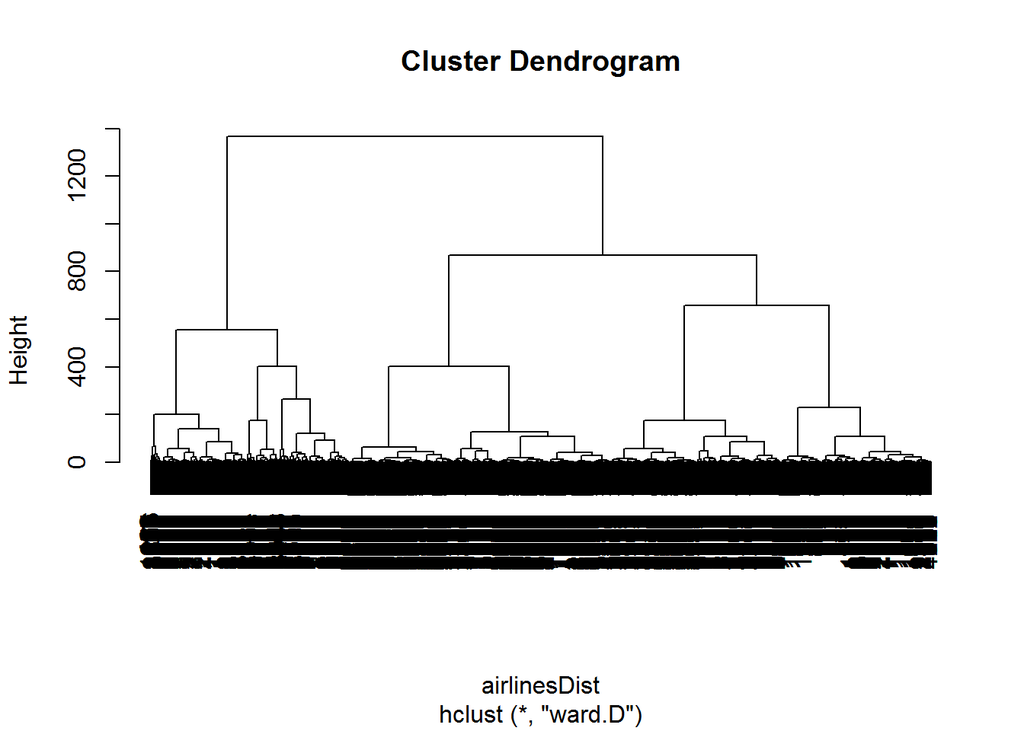

```r
plot(airlinesHierClust)
```

```r
# Pick 5 clusters
clusterGroups = cutree(airlinesHierClust, k = 5)
HierCluster = split(airlinesNorm, clusterGroups)
# Number of data points in cluster 1
nrow(HierCluster[[1]])
```

```
## [1] 776
```

```r
balanceAvg <- tapply(airlines$Balance, clusterGroups, mean)
qualMilesAvg <- tapply(airlines$QualMiles, clusterGroups, mean)
bonusMilesAvg <- tapply(airlines$BonusMiles, clusterGroups, mean)
bonusTransAvg <- tapply(airlines$BonusTrans, clusterGroups, mean)
flightMilesAvg <- tapply(airlines$FlightMiles, clusterGroups, mean)
flightTransAvg <- tapply(airlines$FlightTrans, clusterGroups, mean)
daysAvg <- tapply(airlines$DaysSinceEnroll, clusterGroups, mean)
df <- as.data.frame(cbind(balanceAvg, qualMilesAvg, bonusMilesAvg, bonusTransAvg, flightMilesAvg, flightTransAvg, daysAvg))
which.max(df$balanceAvg);
```

```
## [1] 3
```

```r
which.max(df$qualMilesAvg);
```

```
## [1] 2
```

```r
which.max(df$bonusMilesAvg);
```

```
## [1] 3
```

```r
which.max(df$bonusTransAvg);
```

```
## [1] 3
```

```r
which.max(df$flightMilesAvg);
```

```
## [1] 2
```

```r
which.max(df$flightTransAvg);
```

```
## [1] 2
```

```r
which.max(df$daysAvg)
```

```
## [1] 1
```

## *K-means Clustering*

```r
k = 5
set.seed(88)
KmeansCluster <- kmeans(airlinesNorm, centers = k, iter.max=1000)
airlinesClusters <- KmeansCluster$cluster
table(airlinesClusters) > 1000
```

```
## airlinesClusters
##     1     2     3     4     5
## FALSE FALSE FALSE  TRUE  TRUE
```

```r
KmeansCluster$centers
```

```
##       Balance   QualMiles BonusMiles BonusTrans FlightMiles FlightTrans
## 1  1.44439706  0.51115730  1.8769284  1.0331951   0.1169945   0.1444636
## 2  1.00054098  0.68382234  0.6144780  1.7214887   3.8559798   4.1196141
## 3 -0.05580605 -0.14104391  0.3041358  0.7108744  -0.1218278  -0.1287569
## 4 -0.13331742 -0.11491607 -0.3492669 -0.3373455  -0.1833989  -0.1961819
## 5 -0.40579897 -0.02281076 -0.5816482 -0.7619054  -0.1989602  -0.2196582
##   DaysSinceEnroll
## 1       0.7198040
## 2       0.2742394
## 3      -0.3398209
## 4       0.9640923
## 5      -0.8897747
```

```r
table(clusterGroups)
```

```
## clusterGroups
##    1    2    3    4    5
##  776  519  494  868 1342
```

```r
lapply(split(airlines, clusterGroups), colMeans)
```

```
## $`1`
##         Balance       QualMiles      BonusMiles      BonusTrans
##    5.786690e+04    6.443299e-01    1.036012e+04    1.082345e+01
##     FlightMiles     FlightTrans DaysSinceEnroll
##    8.318428e+01    3.028351e-01    6.235365e+03
##
## $`2`
##         Balance       QualMiles      BonusMiles      BonusTrans
##    1.106693e+05    1.065983e+03    2.288176e+04    1.822929e+01
##     FlightMiles     FlightTrans DaysSinceEnroll
##    2.613418e+03    7.402697e+00    4.402414e+03
##
## $`3`
##         Balance       QualMiles      BonusMiles      BonusTrans
##    1.981916e+05    3.034615e+01    5.579586e+04    1.966397e+01
##     FlightMiles     FlightTrans DaysSinceEnroll
##    3.276761e+02    1.068826e+00    5.615709e+03
##
## $`4`
##         Balance       QualMiles      BonusMiles      BonusTrans
##    52335.913594        4.847926    20788.766129       17.087558
##     FlightMiles     FlightTrans DaysSinceEnroll
##      111.573733        0.344470     2840.822581
##
## $`5`
##         Balance       QualMiles      BonusMiles      BonusTrans
##    3.625591e+04    2.511177e+00    2.264788e+03    2.973174e+00
##     FlightMiles     FlightTrans DaysSinceEnroll
##    1.193219e+02    4.388972e-01    3.060081e+03
```

Compared to other clusters, cluster 1 has the largest average value for ‘DaysSinceEnroll’. This implies that cluster 1 has infrequent but loyal customers.

Similarly, cluster 2 hasthe largest average values for the variables ‘QualMiles’, ‘FlightMiles’ and ‘FlightTrans’. This cluster also has relatively large values in ‘BonusTrans’ and ‘Balance’. This implies that cluster 2 has customers who have accumulated a large amount of miles, mostly through flight transactions.

On the same note, cluster 3 has the largest average values in ‘Balance’, ‘BonusMiles’, and ‘BonusTrans’. While it also has relatively large values in other variables, these are the three for which it has the largest values. This implies that cluster 3 has customers who have accumulated a large amount of miles, mostly through non-flight transactions.

Cluster 4 ,likewise, does not have the largest values in any of the variables. This implies that cluster 4 has relatively new customers (since they have the smallest value in ‘DaysSinceEnroll’) who seem to be accumulating miles mostly through non-flight transactions.

Finally, cluster 5 also does not have the largest values in any of the variables. This implies that cluster 5 has relatively new customers who do not use the airlines very often.(since they have lower than average values in all the variables.)

Results

We segmented the frequent flyers of an airline into clusters for targeted marketing and we were able to identify 5 unique clusters with varying properties.

Cluster 1: infrequent but loyal customers

Cluster 2: customers with huge miles procured through flight transactions

Cluster 3: customers with huge miles procured through non-flight transactions

Cluster 4: new customers procuring miles through non-flight transactions

Cluster 5: infrequent and new customers